实验6：自然语言处理

# 实验简介

本实验以豆瓣（douban.com）中文影评情感分析问题为例，介绍如何利用深度学习技术搭建自然语言处理系统。

在本实验中，我们将搭建一个LSTM模型，用于完成对电影评价文本的情感分类（积极评价或消极评价），并评估模型效果。通过本实验，你将掌握以下技能：

- 了解中文自然语言处理任务中常用的工具；
- 了解自然语言处理中数据预处理、数据加载和模型训练的一般流程；
- 了解情感分析模型的构建方法。

# 实验数据下载

通过以下链接下载实验所需数据及预训练权重文件：[[Link]](https://pan.baidu.com/s/1mLcPTgb2m5HPgkT3XcGVCg)（提取码：n41n）

数据下载完成后，解压到当前Notebook文件所在目录下（不需要建立子目录）。

数据下载过程中，可同步进行实验环境准备。

本实验中使用的数据是通过网络爬虫获取的豆瓣电影影评数据，并已预先根据网页上的“好评”、“差评”选项进行了标注。

[figure not shown]

# 实验环境准备

安装本实验所需的必要组件。

## 安装Miniconda

从以下链接下载Miniconda安装包并完成安装[[Link]](https://mirrors.tuna.tsinghua.edu.cn/anaconda/miniconda/Miniconda3-py310_24.1.2-0-Windows-x86_64.exe)，安装过程中需要选中`Register Anaconda as my default Python 3.10`。若计算机上已经安装好Miniconda或Anaconda，请跳过此步骤。

## 安装必要的Package

在`Anaconda Prompt`中，通过`pip`包管理器安装`Jupyter Notebook`、`PyTorch`、`Gensim`、`jieba`、`tqdm`及`zhconv`包。

```
pip install notebook -i https://pypi.tuna.tsinghua.edu.cn/simple/
pip install torch -i https://pypi.tuna.tsinghua.edu.cn/simple/
pip install gensim -i https://pypi.tuna.tsinghua.edu.cn/simple/
pip install jieba -i https://pypi.tuna.tsinghua.edu.cn/simple/
pip install tqdm -i https://pypi.tuna.tsinghua.edu.cn/simple/
pip install zhconv -i https://pypi.tuna.tsinghua.edu.cn/simple/
```

当然，可以直接通过以下命令进行全局修改，而不必每次都指定`-i`参数：

```
pip config set global.index-url https://pypi.tuna.tsinghua.edu.cn/simple
```

你可以通过执行以下Python代码，检查上述包是否已经安装完成。

```python
import pkgutil

# 检查PyTorch是否已安装
if pkgutil.find_loader('torch'):
    print('PyTorch is available.')

# 检查Gensim是否已安装
if pkgutil.find_loader('gensim'):
    print('Gensim is available.')

# 检查jieba是否已安装
if pkgutil.find_loader('jieba'):
    print('jieba is available.')

# 检查tqdm是否已安装
if pkgutil.find_loader('tqdm'):
    print('tqdm is available.')

# 检查zhconv是否已安装
if pkgutil.find_loader('zhconv'):
    print('zhconv is available.')
```

```
PyTorch is available.
Gensim is available.
jieba is available.
tqdm is available.
zhconv is available.
```

# 基础参数配置

首先导入必要的Package。

```python
import torch
import os
import random
import re
import gensim
import jieba
import numpy as np

from tqdm.notebook import tqdm
from zhconv import convert

from torch import nn
from torch.utils.data import Dataset, DataLoader
import torch.optim as optim
from torch.utils.tensorboard import SummaryWriter
from torch.nn.utils.rnn import pad_sequence, pack_padded_sequence, pad_packed_sequence
```

```python
# 忽略Warning输出
import warnings
warnings.filterwarnings("ignore")
```

创建一个`DictObj`类，用于存储必要的配置信息，方便后续使用。

定义`Config`对象，指定默认的配置信息（包括数据存放的位置、模型超参数等）。

```python
class DictObj(object):
    def __init__(self, mp):
        self.map = mp

    def __setattr__(self, name, value):
        if name == 'map':
            object.__setattr__(self, name, value)
            return
        self.map[name] = value

    def __getattr__(self, name):
        return self.map[name]

Config = DictObj({
    'train_path' : './train.txt',
    'test_path' : './test.txt',
    'validation_path' : './validation.txt',
    'pred_word2vec_path': './wiki_word2vec_50.bin',
    'tensorboard_path':'./tensorboard',
    'model_save_path':'./model/model.pth',
    'embedding_dim':50,
    'hidden_dim':100,
    'lr':0.001,
    'LSTM_layers':3,
    'drop_prob': 0.5,
    'seed':0
})
```

# 数据预处理

## 构建词汇表

利用训练数据构建词汇表，实现词与索引之间的转换。

构建词汇表的逻辑是：首先读取训练集数据，利用`zhconv`包将少部分繁体中文影评数据统一转换为简体中文。训练数据本身已经进行了分词，因此只需读入数据，再进行去重，即可构建词与索引的转换字典。

```python
def build_word_dict(train_path):
    words = []
    max_len = 0
    total_len = 0
    with open(train_path,'r',encoding='UTF-8') as f:
        lines = f.readlines()
        for line in  lines:
            line = convert(line, 'zh-cn')
            line_words = re.split(r'[\s]', line)[1:-1]
            max_len = max(max_len, len(line_words))
            total_len += len(line_words)
            for w in line_words:
                words.append(w)

    words = list(set(words))
    words = sorted(words)

    word2ix = {w:i+1 for i,w in enumerate(words)}
    ix2word = {i+1:w for i,w in enumerate(words)}
    word2ix['<unk>'] = 0
    ix2word[0] = '<unk>'
    avg_len = total_len / len(lines)
    return word2ix, ix2word, max_len, avg_len
```

```python
word2ix, ix2word, max_len, avg_len = build_word_dict(Config.train_path)
print(f'影评的最大长度为：{max_len}，平均长度为：{avg_len}。')
```

```
影评的最大长度为：679，平均长度为：44.67896789678968。
```

## 变长数据的处理

一般而言，LSTM等RNN类的神经网络模型能够接受变长输入，也就是说，对于任意长度的影评数据，都不需要对模型结构进行改变。然而，深度学习框架（如`PyTorch`）通常是以`batch`为单位进行训练的，这就涉及到变长序列的统一处理问题。目前常用的处理方法是，对文本数据按长度进行排序，之后按批次分别进行填充（Padding）处理，也就是LSTM单元数量总是取同一个批次最大的文本长度，长度不足的数据则使用零填充方法补齐长度。

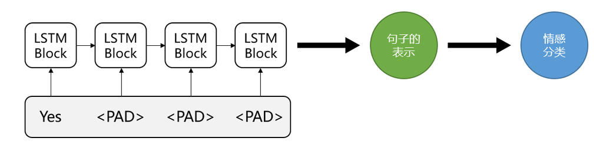

```python
def mycollate_fn(data):
    # 这里的data是getittem返回的（input，label）的二元组，总共有batch_size个
    data.sort(key=lambda x: len(x[0]), reverse=True)  # 根据input来排序
    data_length = [len(sq[0]) for sq in data]
    input_data = []
    label_data = []
    for i in data:
        input_data.append(i[0])
        label_data.append(i[1])
    input_data = pad_sequence(input_data, batch_first=True, padding_value=0)
    label_data = torch.tensor(label_data)
    return input_data, label_data, data_length
```

## 数据集类的定义

定义一个影评数据集类，提供空白字符处理等基本功能。

```python
class CommentDataSet(Dataset):
    def __init__(self, data_path, word2ix, ix2word):
        self.data_path = data_path
        self.word2ix = word2ix
        self.ix2word = ix2word
        self.data, self.label = self.get_data_label()

    def __getitem__(self, idx: int):
        return self.data[idx], self.label[idx]

    def __len__(self):
        return len(self.data)

    def get_data_label(self):
        data = []
        label = []
        with open(self.data_path, 'r', encoding='UTF-8') as f:
            lines = f.readlines()
            for line in lines:
                try:
                    label.append(torch.tensor(int(line[0]), dtype=torch.int64))
                except BaseException:  # 遇到首个字符不是标签的就跳过比如空行，并打印
                    print('not expected line:' + line)
                    continue
                line = convert(line, 'zh-cn')  # 转换成大陆简体
                line_words = re.split(r'[\s]', line)[1:-1]  # 按照空字符\t\n 空格来切分
                words_to_idx = []
                for w in line_words:
                    try:
                        index = self.word2ix[w]
                    except BaseException:
                        index = 0  # 测试集，验证集中可能出现没有收录的词语，置为0
                    words_to_idx.append(index)
                data.append(torch.tensor(words_to_idx, dtype=torch.int64))
        return data, label
```

## 数据集划分

根据配置信息构建训练集、验证集、测试集，并创建数据加载器（DataLoader）。

```python
train_data = CommentDataSet(Config.train_path, word2ix, ix2word)
train_loader = DataLoader(train_data, batch_size=16, shuffle=True,
                          num_workers=0, collate_fn=mycollate_fn,)

validation_data = CommentDataSet(Config.validation_path, word2ix, ix2word)
validation_loader = DataLoader(validation_data, batch_size=16, shuffle=True,
                               num_workers=0, collate_fn=mycollate_fn,)

test_data = CommentDataSet(Config.test_path, word2ix, ix2word)
test_loader = DataLoader(test_data, batch_size=16, shuffle=False,
                         num_workers=0, collate_fn=mycollate_fn,)
```

```
not expected line:

not expected line:
```

# 模型构建

## Word2vec预训练权重加载

使用`Gensim`加载中文Word2vec预训练权重，结合之前创建的词汇表，初始化Embedding层。

```python
word2vec_model = gensim.models.KeyedVectors.load_word2vec_format(Config.pred_word2vec_path, binary=True)

def pre_weight(vocab_size):
    weight = torch.zeros(vocab_size,Config.embedding_dim)
    #初始权重
    for i in range(len(word2vec_model.index_to_key)):  #预训练中没有word2ix，所以只能用索引来遍历
        try:
            index = word2ix[word2vec_model.index_to_key[i]]  #得到预训练中的词汇的新索引
        except:
            continue
        weight[index, :] = torch.from_numpy(word2vec_model.get_vector(
            ix2word[word2ix[word2vec_model.index_to_key[i]]]))  #得到对应的词向量
    return weight
```

## 模型结构定义

使用PyTorch自带的LSTM模块创建模型，并在其后添加3个全连接层用于完成分类任务。

```python
class SentimentModel(nn.Module):
    def __init__(self, embedding_dim, hidden_dim,pre_weight):
        super(SentimentModel, self).__init__()
        self.hidden_dim = hidden_dim
        self.embeddings = nn.Embedding.from_pretrained(pre_weight)
        self.embeddings.weight.requires_grad = True
        self.lstm = nn.LSTM(embedding_dim, self.hidden_dim, num_layers=Config.LSTM_layers,
                            batch_first=True, dropout=Config.drop_prob, bidirectional=False)
        self.dropout = nn.Dropout(Config.drop_prob)
        self.fc1 = nn.Linear(self.hidden_dim,256)
        self.fc2 = nn.Linear(256,32)
        self.fc3 = nn.Linear(32,2)

    def forward(self, input, batch_seq_len, hidden=None):
        embeds = self.embeddings(input)
        embeds = pack_padded_sequence(embeds,batch_seq_len, batch_first=True)
        batch_size, seq_len = input.size()
        if hidden is None:
            h_0 = input.data.new(Config.LSTM_layers*1, batch_size, self.hidden_dim).fill_(0).float()
            c_0 = input.data.new(Config.LSTM_layers*1, batch_size, self.hidden_dim).fill_(0).float()
        else:
            h_0, c_0 = hidden
        output, hidden = self.lstm(embeds, (h_0, c_0))
        output,_ = pad_packed_sequence(output,batch_first=True)

        output = self.dropout(torch.tanh(self.fc1(output)))
        output = torch.tanh(self.fc2(output))
        output = self.fc3(output)
        last_outputs = self.get_last_output(output, batch_seq_len)
        return last_outputs,hidden

    def get_last_output(self,output,batch_seq_len):
        last_outputs = torch.zeros((output.shape[0],output.shape[2]))
        for i in range(len(batch_seq_len)):
            last_outputs[i] =  output[i][batch_seq_len[i]-1]
        last_outputs = last_outputs.to(output.device)
        return last_outputs
```

## 模型性能评价指标

使用TopK的`AverageMeter`及混淆矩阵（`ConfuseMeter`）用于模型评价。

```python
class AvgrageMeter(object):
    def __init__(self):
        self.reset()

    def reset(self):
        self.avg = 0
        self.sum = 0
        self.cnt = 0

    def update(self, val, n=1):
        self.sum += val * n
        self.cnt += n
        self.avg = self.sum / self.cnt

class ConfuseMeter(object):
    def __init__(self):
        self.reset()

    def reset(self):
        self.confuse_mat = torch.zeros(2,2)
        self.tp = self.confuse_mat[0,0]
        self.fp = self.confuse_mat[0,1]
        self.tn = self.confuse_mat[1,1]
        self.fn = self.confuse_mat[1,0]
        self.acc = 0
        self.pre = 0
        self.rec = 0
        self.F1 = 0

    def update(self, output, label):
        pred = output.argmax(dim = 1)
        for l, p in zip(label.view(-1),pred.view(-1)):
            self.confuse_mat[p.long(), l.long()] += 1
        self.tp = self.confuse_mat[0,0]
        self.fp = self.confuse_mat[0,1]
        self.tn = self.confuse_mat[1,1]
        self.fn = self.confuse_mat[1,0]
        self.acc = (self.tp+self.tn) / self.confuse_mat.sum()
        self.pre = self.tp / (self.tp + self.fp)
        self.rec = self.tp / (self.tp + self.fn)
        self.F1 = 2 * self.pre*self.rec / (self.pre + self.rec)

def accuracy(output, label, topk=(1,)):
    maxk = max(topk)
    batch_size = label.size(0)

    _, pred = output.topk(maxk, 1, True, True) #使用topk来获得前k个的索引
    pred = pred.t()
    correct = pred.eq(label.view(1, -1).expand_as(pred)) # 与正确标签序列形成的矩阵相比，生成True/False矩阵

    rtn = []
    for k in topk:
        correct_k = correct[:k].reshape(-1).float().sum(0)
        rtn.append(correct_k.mul_(100.0 / batch_size))
    return rtn
```

# 模型训练

## 定义训练、验证及测试函数

定义训练函数，该函数包含了单个epoch的训练逻辑。

```python
def train(epoch,epochs, train_loader, device, model, criterion, optimizer,scheduler,tensorboard_path):
    model.train()
    top1 = AvgrageMeter()
    model = model.to(device)
    train_loss = 0.0
    for i, data in enumerate(train_loader, 0):
        inputs, labels, batch_seq_len = data[0].to(device), data[1].to(device), data[2]
        # 初始为0，清除上个batch的梯度信息
        optimizer.zero_grad()
        outputs,hidden = model(inputs,batch_seq_len)

        loss = criterion(outputs,labels)
        loss.backward()
        optimizer.step()
        _,pred = outputs.topk(1)
        prec1, prec2= accuracy(outputs, labels, topk=(1,2))
        n = inputs.size(0)
        top1.update(prec1.item(), n)
        train_loss += loss.item()
        postfix = {'train_loss': '%.6f' % (train_loss / (i + 1)), 'train_acc': '%.6f' % top1.avg}
        train_loader.set_postfix(log=postfix)

        # ternsorboard 曲线绘制
        if os.path.exists(tensorboard_path) == False:
            os.mkdir(tensorboard_path)
        writer = SummaryWriter(tensorboard_path)
        writer.add_scalar('Train/Loss', loss.item(), epoch)
        writer.add_scalar('Train/Accuracy', top1.avg, epoch)
        writer.flush()

    scheduler.step()
```

类似地，定义验证、测试函数。

```python
def validate(epoch,validate_loader, device, model, criterion, tensorboard_path):
    val_acc = 0.0
    model = model.to(device)
    model.eval()
    with torch.no_grad():  # 进行评测的时候网络不更新梯度
        val_top1 = AvgrageMeter()
        validate_loader = tqdm(validate_loader)
        validate_loss = 0.0
        for i, data in enumerate(validate_loader, 0):
            inputs, labels, batch_seq_len = data[0].to(device), data[1].to(device), data[2]
            outputs,_ = model(inputs, batch_seq_len)
            loss = criterion(outputs, labels)

            prec1, prec2 = accuracy(outputs, labels, topk=(1, 2))
            n = inputs.size(0)
            val_top1.update(prec1.item(), n)
            validate_loss += loss.item()
            postfix = {'validate_loss': '%.6f' % (validate_loss / (i + 1)), 'validate_acc': '%.6f' % val_top1.avg}
            validate_loader.set_postfix(log=postfix)

            # ternsorboard 曲线绘制
            if os.path.exists(tensorboard_path) == False:
                os.mkdir(tensorboard_path)
            writer = SummaryWriter(tensorboard_path)
            writer.add_scalar('Validate/Loss', loss.item(), epoch)
            writer.add_scalar('Validate/Accuracy', val_top1.avg, epoch)
            writer.flush()
        val_acc = val_top1.avg
    return val_acc

def test(validate_loader, device, model, criterion):
    val_acc = 0.0
    model = model.to(device)
    model.eval()
    confuse_meter = ConfuseMeter()
    with torch.no_grad():  # 进行评测的时候网络不更新梯度
        val_top1 = AvgrageMeter()
        validate_loader = tqdm(validate_loader)
        validate_loss = 0.0
        for i, data in enumerate(validate_loader, 0):
            inputs, labels, batch_seq_len = data[0].to(device), data[1].to(device), data[2]
            outputs,_ = model(inputs, batch_seq_len)
            prec1, prec2 = accuracy(outputs, labels, topk=(1, 2))
            n = inputs.size(0)
            val_top1.update(prec1.item(), n)
            confuse_meter.update(outputs, labels)
            postfix = { 'test_acc': '%.6f' % val_top1.avg,
                      'confuse_acc': '%.6f' % confuse_meter.acc}
            validate_loader.set_postfix(log=postfix)
        val_acc = val_top1.avg
    return confuse_meter
```

## 设置随机种子

设置随机种子，保证模型在每次初始化时得到的是相同的权重，保证结果的可复现性。

```python
def set_seed(seed):
    np.random.seed(seed)
    random.seed(seed)
    torch.manual_seed(seed)
    if torch.cuda.is_available():
        torch.cuda.manual_seed_all(seed)
        torch.backends.cudnn.deterministic = True
```

```python
set_seed(Config.seed)
```

## 模型初始化

```python
model = SentimentModel(embedding_dim=Config.embedding_dim,
                       hidden_dim=Config.hidden_dim,
                       pre_weight=pre_weight(len(word2ix)))
device = torch.device("cuda:0" if torch.cuda.is_available() else "cpu")
optimizer = optim.Adam(model.parameters(), lr=Config.lr)
scheduler = torch.optim.lr_scheduler.StepLR(optimizer, step_size = 10, gamma=0.1)
criterion = nn.CrossEntropyLoss()
print(model)
```

```
SentimentModel(
  (embeddings): Embedding(51404, 50)
  (lstm): LSTM(50, 100, num_layers=3, batch_first=True, dropout=0.5)
  (dropout): Dropout(p=0.5, inplace=False)
  (fc1): Linear(in_features=100, out_features=256, bias=True)
  (fc2): Linear(in_features=256, out_features=32, bias=True)
  (fc3): Linear(in_features=32, out_features=2, bias=True)
)
```

## 模型迭代训练

因为使用tensorboard画图会产生很多日志文件，这里进行清空操作。

```python
import shutil
if os.path.exists(Config.tensorboard_path):
    shutil.rmtree(Config.tensorboard_path)
    os.mkdir(Config.tensorboard_path)
```

使用CPU进行训练时，每个epoch约耗时3~5分钟，可根据实际算力进行调整。

```python
epochs = 3  # 按需调整

for epoch in range(epochs):
    train_loader = tqdm(train_loader)
    train_loader.set_description('[%s%04d/%04d %s%f]' % ('Epoch:', epoch + 1, epochs, 'lr:', scheduler.get_lr()[0]))
    train(epoch, epochs, train_loader, device, model, criterion, optimizer,scheduler, Config.tensorboard_path)
    validate(epoch, validation_loader,device,model,criterion,Config.tensorboard_path)
```

```python
#模型保存
if os.path.exists(Config.model_save_path) == False:
    os.mkdir('./model/')
torch.save(model.state_dict(), Config.model_save_path)
```

# 模型测试

在测试集上评估模型性能，包括准确率、召回率、F1值及混淆矩阵。

```python
model_test = SentimentModel(embedding_dim=Config.embedding_dim,
                            hidden_dim=Config.hidden_dim,
                            pre_weight=pre_weight(len(word2ix)))
optimizer_test = optim.Adam(model_test.parameters(), lr=Config.lr)
scheduler_test = torch.optim.lr_scheduler.StepLR(optimizer, step_size = 10, gamma=0.1)
criterion_test = nn.CrossEntropyLoss()
model_test.load_state_dict(torch.load(Config.model_save_path), strict=True)
```

```
<All keys matched successfully>
```

```python
confuse_meter = ConfuseMeter()
confuse_meter = test(test_loader,device,model_test,criterion_test)
print('prec:%.6f  recall:%.6f  F1:%.6f'%(confuse_meter.pre,confuse_meter.rec, confuse_meter.F1))
```

```
prec:0.511236  recall:1.000000  F1:0.676580
```

```python
confuse_meter.confuse_mat
```

```
tensor([[182., 174.],
        [  0.,  13.]])
```

# 使用模型进行推理

为方便使用，定义一个预测函数。

```python
def predict(comment_str, model=model, device=device):
    model = model.to(device)
    seg_list = jieba.lcut(comment_str, cut_all=False)
    words_to_idx = []
    for w in seg_list:
        try:
            index = word2ix[w]
        except:
            index = 0
        words_to_idx.append(index)
    inputs = torch.tensor(words_to_idx).to(device)
    inputs = inputs.reshape(1,len(inputs))
    outputs,_ = model(inputs, [len(inputs),])
    pred = outputs.argmax(1).item()
    if pred:
        print("Negative")
    else:
        print("Positive")
    return pred
```

使用一些影评字符串进行测试。

```python
comment_str = "这一部导演、监制、男一都和《怒晴湘西》都是原班人马，这次是黄土高原上《龙岭密窟》的探险故事，有蝙蝠群、巨型蜘蛛这些让人瑟瑟发抖的元素，紧张刺激的剧情挺期待的。潘老师演技一如既往地稳。本来对姜超的印象也还在李大嘴这个喜剧角色里，居然没让人失望，还挺贴合王胖子这个角色。"
predict(comment_str)
```

```
Building prefix dict from the default dictionary ...
Loading model from cache C:\Users\Lenovo\AppData\Local\Temp\jieba.cache
Loading model cost 0.565 seconds.
Prefix dict has been built successfully.
```

```
Positive
```

```
0
```

```python
comment_str = "年代感太差，剧情非常的拖沓，还是冗余情节的拖沓。特效五毛，实在是太烂。潘粤明对这剧也太不上心了，胖得都能演王胖子了，好歹也锻炼一下。烂剧！"
predict(comment_str,model,device)
```

```
Negative
```

```
1
```

> **尝试自己编写一些影评文本，观察模型输出结果是否符合预期。**